# Assignment 09

Statistical Computing and Empirical Methods

## A word of advice

Think of the SCEM labs like going to the gym: if you pay for gym membership, but instead of working out you use a machine to lift the weights for you, you won’t grow any muscle.

ChatGPT, DeepSeek, Claude and other GenAI tools can provide answers to most of the questions below. Before you try that, please consider the following: answering the specific questions below is not the point of this assignment. Instead, the questions are designed to give you the chance to develop a better understanding of estimation concepts and a certain level of **statistical thinking**. These are essential skills for any data scientist, even if they end up using generative AI - to write an effective prompt and to catch the common (often subtle) errors that AI produces when trying to solve anything non-trivial.

A very important part of this learning involves not having the answers ready-made for you but instead taking the time to actually search for the answer, trying something, getting it wrong, and trying again.

So, make the best use of this session. The assignments are not marked, so it is much better to try them yourself even if you get incorrect answers (you’ll be able to correct yourself later when you receive feedback) than to submit a perfect, but GPT’d solution.

## Introduction

Before starting, make sure you have reviewed the Week 9 lecture slides.

This assignment will be done in **RStudio**. **You do not need to submit anything for this assessment.** Feedback will be provided on the labs.

## Introduction

In this lab we will discuss the final steps of CRISP-DM (modelling, evaluation and deployment), which corresponds to the final parts of Task II in the coursework.

There are several packages that implement different predictive models in R. Within the *tidyverse*, the most useful R meta-package for the entire modelling cycle is called *tidymodels*, which contains packages implementing all relevant components usually required in supervised learning. The most relevant for today’s lab are the following:

- [`rsample`](https://rsample.tidymodels.org) has infrastructure for data resampling and splitting, so that models can be assessed and empirically validated.
- [`recipes`](https://recipes.tidymodels.org) is a general data preprocessor with a modern interface. It can create model matrices that incorporate feature engineering, imputation, and other help tools.
- [`parsnip`](https://parsnip.tidymodels.org) is a tidy, unified interface to creating models.
- [`dials`](https://dials.tidymodels.org) has tools to create and manage values of tuning parameters.
- [`tune`](https://tune.tidymodels.org) contains the functions to optimize model hyper-parameters.
- [`workflows`](https://workflows.tidymodels.org) has methods to combine pre-processing steps and models into a single object.
- [`yardstick`](https://yardstick.tidymodels.org) contains tools for evaluating models (e.g. accuracy, RMSE, etc.).

In this lab, we’ll work on the same credit scoring data from last week. To recall, the credit scoring data has the following columns:

- `Status`: credit status (**the target variable**)
- `Seniority`: job seniority in years
- `Home`: type of home ownership
- `Time`: time of requested loan
- `Age`: client’s age
- `Marital`: marital status
- `Records`: existance of records
- `Job`: type of job
- `Expenses`: amount of expenses
- `Income`: amount of income
- `Assets`: amount of assets
- `Debt`: amount of debt
- `Amount`: amount requested of loan
- `Price`: price of good

## Part 1 - recapping from last week: data loading and preprocessing recipe

Let’s start by loading and splitting the data. From last week’s exploration, we already knew that there are ~4500 observations and that the class attribute is a bit imbalanced, with a 28:72 bad-to-good ratio, no missing values on the target variable, a few scattered missing values and no grouping structure. We’ll replicate the splitting that we used last week, *stratifying* the splits by the target variable to ensure that the same class balance is retained across both the *model development* and the *test* sets.

```r
## Load data
X <- modeldata::credit_data

set.seed(20251119) # Same seed as last week, to re-generate the same splits

# Generate random splits with stratification on the target variable
mysplits <- initial_split(X, prop = .8, strata = "Status")
# NOTE: if we had a grouping variable, we would use "group_initial_split(X, ..., group = "grouping_variable)" instead.

# Attribute the splits generated by initial_splits() to specific variables that we can operate on
Xmod     <- training(mysplits)
Xtest    <- testing(mysplits)
rm(X)
```

From last week’s EDA, we also know that there were a few data issues that required the following preprocessing steps:

- Mode imputation for variables `Home`, `Job`, `Marital` and `Records`
- Variable `Home`: combine level “ignore” into “other”
- Variable `Marital`: combine “divorced” with “separated”.
- Variables `Age`, `Amount`, `Income`, `Price`, `Expenses`, `Seniority` and `Time`: Imputation by winsorised mean.
- Variables `Age`, `Amount`, `Income`, `Price`, `Expenses` and `Seniority`: log transformation (using `log1p()` to deal with zeros).
- Variables `Age`, `Amount`, `Income` and `Price`: winsorisation
- Variables `Age`, `Amount`, `Income`, `Price`, `Expenses`, `Seniority` and `Time`: scaling by normalisation
- Variables `Debt` and `Asset`: kNN-based imputation followed by ordinal encoding
- Dimensionality reduction using PCA (for numerical predictors)
- one-hot encoding (for categorical predictors)

```r
# Build preprocessing recipe:
dpp.stack <- recipe(Status ~ ., data = Xmod) %>%
  # mode imputation
  step_impute_mode(all_factor_predictors()) %>%
  # collapse factor levels using fct_collapse() from package `forcats`
  step_mutate(Home = fct_collapse(Home, other = c("other", "ignore"))) %>%
  step_mutate(Marital = fct_collapse(Marital, Unmarried = c("divorced", "separated"))) %>%
  # Imputation by winsorised mean
  step_impute_mean(all_numeric_predictors(), -Debt, -Assets, trim = 0.1) %>%
  # Log transformation
  step_mutate_at(all_numeric_predictors(), -Debt, -Assets, -Time, fn = ~log1p(.x)) %>%
  # Winsorisation at 5% (less extreme than the one used in the mean imputation)
  step_hai_winsorized_truncate(Age, Amount, Income, Price, fraction = .05) %>%
  # Remove pre-winsorisation versions of affected variables
  step_rm(Age, Amount, Income, Price) %>%
  # Normalisation scaling
  step_normalize(all_numeric_predictors(), -Debt, -Assets) %>%
  # kNN imputation
  step_impute_knn(Debt, Assets) %>%
  # Ordinal encoding
  step_cut(Debt, breaks = c(0.001, 500, 1000, 5000),
           include_outside_range = TRUE) %>%
  step_cut(Assets, breaks = c(0.001, 1000, 10000, 100000),
           include_outside_range = TRUE) %>%
  # PCA on the numeric predictors, retaining at least 90%
  # of the total variability of the original features
  step_pca(all_numeric_predictors(), threshold = 0.9) %>%
  # Ensure that nominal predictors don't break if unseen levels appear in test/new data.
  step_novel(all_factor_predictors()) %>%
  # One-hot encoding of factor variables
  step_dummy(all_factor_predictors())
```

## Part II - defining a baseline model

Let’s start by defining a basic predictive model, and evaluating it using cross validation. In this week’s lecture we used the linear model *logistic regression* as an example, so let’s try a different one here: a *decision tree*

```r
dt.model <- decision_tree() %>%
  set_mode(mode = "classification") %>% # To make sure we're building a classification model
  set_engine(engine = "rpart")          # The underlying model engine. Check model documentation for details.
```

If you look at the documentation of the documentation of `decision_tree()`, you’ll notice that this model has two hyperparameters that we could have set: `tree_depth` and `min_n`. By default, these hyperparameters receive standard values without user input, but we could have passed explicit values, or left them as tunable parameters (using `tune()`) if we wished

Once we have a model definition, we can put the preprocessing and model parts together into a *workflow*, which is a unified *learnable object*:

```r
first_wf <- workflow() %>%
  add_recipe(dpp.stack) %>%
  add_model(dt.model)

first_wf
## ══ Workflow ════════════════════════════════════════════════════════════════════
## Preprocessor: Recipe
## Model: decision_tree()
##
## ── Preprocessor ────────────────────────────────────────────────────────────────
## 14 Recipe Steps
##
## • step_impute_mode()
## • step_mutate()
## • step_mutate()
## • step_impute_mean()
## • step_mutate_at()
## • step_hai_winsorized_truncate()
## • step_rm()
## • step_normalize()
## • step_impute_knn()
## • step_cut()
## • ...
## • and 4 more steps.
##
## ── Model ───────────────────────────────────────────────────────────────────────
## Decision Tree Model Specification (classification)
##
## Computational engine: rpart
```

As meantioned above, this workflow represents a consolidated object that can be *learned* from the training data and later *assessed* or *deployed*. Putting all learnable elements of a predictive pipeline into this sort of standardised object is considered good practice, as it makes it easier not to inadvertently apply some transformation on the model development data that is later forgotten when deploying the model.

We can easily fit and assess this first workflow using cross-validation. For that, we need to define the cross-validation folds, then use them to perform multiple fit/eval cycles, and finally extract the consolidated (average) performance. We’ll use a basic 5-fold cross validation.

( *Important: any specific data aspects that were considered important in the original train/test splitting - such as stratification or grouping - needs to also be considered for any other later splitting, including cross-validation.* )

```r
set.seed(20191126)

# Define cross-validation folds
folds <- vfold_cv(Xmod, v = 5, strata = "Status")

# Fit the model using the cross-validation splits
first_wf_fit <- first_wf %>%
  fit_resamples(folds, metrics = metric_set(accuracy, roc_auc, ppv, npv, f_meas))
```

This routine already fits and assesses the model multiple times, using the cross-validation folds, and collects the named performance metrics for each case. We can query the performance values using:

```r
collect_metrics(first_wf_fit)
```

```
## # A tibble: 5 × 6
##   .metric  .estimator  mean     n std_err .config
##   <chr>    <chr>      <dbl> <int>   <dbl> <chr>
## 1 accuracy binary     0.762     5 0.00582 pre0_mod0_post0
## 2 f_meas   binary     0.468     5 0.0183  pre0_mod0_post0
## 3 npv      binary     0.788     5 0.00503 pre0_mod0_post0
## 4 ppv      binary     0.631     5 0.0142  pre0_mod0_post0
## 5 roc_auc  binary     0.699     5 0.0134  pre0_mod0_post0
```

We can think about these values as our baseline performance estimates: we obtained those using a reasonably simple model (albeit with an already complex preprocessing stack) and without any tuning. PPV and NPV provide a neat breakdown of the reliability of model predictions for the positive and negative cases, respectively ( *note: by default, the “positive” class corresponds to the first (alphabetically) class label of the target variable* ).

There are different things we could do now: we could try using more complex model, such as a random forest (using `rand_forest()`) or a neural network (using `mlp()`); or try to perform some hyperparameter tuning on the basic model to see if we can improve its performance.

We’ll leave the exploration of more complex models as something you can try later, and focus on hyperparameter tuning. Let’s assume that we only want to optimise the two hyperparameters of the decision tree. We can set this experiment up as follows:

```r
# redefine the model with tunable parameters:
dt.model2 <- decision_tree(tree_depth = tune(), min_n = tune()) %>%
  set_mode(mode = "classification") %>%
  set_engine(engine = "rpart")

wf_second <- workflow() %>%
  add_recipe(dpp.stack) %>%
  add_model(dt.model2)

wf_second
## ══ Workflow ════════════════════════════════════════════════════════════════════
## Preprocessor: Recipe
## Model: decision_tree()
##
## ── Preprocessor ────────────────────────────────────────────────────────────────
## 14 Recipe Steps
##
## • step_impute_mode()
## • step_mutate()
## • step_mutate()
## • step_impute_mean()
## • step_mutate_at()
## • step_hai_winsorized_truncate()
## • step_rm()
## • step_normalize()
## • step_impute_knn()
## • step_cut()
## • ...
## • and 4 more steps.
##
## ── Model ───────────────────────────────────────────────────────────────────────
## Decision Tree Model Specification (classification)
##
## Main Arguments:
##   tree_depth = tune()
##   min_n = tune()
##
## Computational engine: rpart
```

```r
set.seed(20251126)

# Set up a 5 x 5 grid
dt.grid <- grid_regular(min_n(),
                        tree_depth(),
                        levels = 5)

# Since tuning will require 125 instances of model fitting and assessment,
# let's reduce the number of CV folds to 3 to make it less time-consuming
tune.folds <- vfold_cv(Xmod, v = 3, strata = "Status")
```

Finally, let’s run the tuning (note: this may take some time):

```r
set.seed(20251126)
dt.tuned <- wf_second %>%
  tune_grid(resamples = tune.folds,
            grid = dt.grid,
            metrics = metric_set(roc_auc, ppv, npv, accuracy),
            control = control_grid(verbose = FALSE)) # Set to TRUE of you want to look at it while it runs

dt.tuned
## # Tuning results
## # 3-fold cross-validation using stratification
## # A tibble: 3 × 4
##   splits              id    .metrics           .notes
##   <list>              <chr> <list>             <list>
## 1 <split [2374/1189]> Fold1 <tibble [100 × 6]> <tibble [0 × 4]>
## 2 <split [2376/1187]> Fold2 <tibble [100 × 6]> <tibble [0 × 4]>
## 3 <split [2376/1187]> Fold3 <tibble [100 × 6]> <tibble [0 × 4]>
```

Once the tuning is finished, we can both explore them and select the best result. `collect_metrics()` returns a data frame with all the results (one row per <configuration, metric> pair), which is useful if you want to investigate the effects of some hyperparameters on the performance of the workflow:

```r
collect_metrics(dt.tuned)
```

```
## # A tibble: 100 × 8
##    tree_depth min_n .metric  .estimator  mean     n std_err .config
##         <int> <int> <chr>    <chr>      <dbl> <int>   <dbl> <chr>
##  1          1     2 accuracy binary     0.736     3 0.00742 pre0_mod01_post0
##  2          1     2 npv      binary     0.775     3 0.00360 pre0_mod01_post0
##  3          1     2 ppv      binary     0.553     3 0.0223  pre0_mod01_post0
##  4          1     2 roc_auc  binary     0.615     3 0.00782 pre0_mod01_post0
##  5          1    11 accuracy binary     0.736     3 0.00742 pre0_mod02_post0
##  6          1    11 npv      binary     0.775     3 0.00360 pre0_mod02_post0
##  7          1    11 ppv      binary     0.553     3 0.0223  pre0_mod02_post0
##  8          1    11 roc_auc  binary     0.615     3 0.00782 pre0_mod02_post0
##  9          1    21 accuracy binary     0.736     3 0.00742 pre0_mod03_post0
## 10          1    21 npv      binary     0.775     3 0.00360 pre0_mod03_post0
## # ℹ 90 more rows
```

You can use these results to plot how the performance of your models varies as a function of hyperparameter values, or perform other visualisation / exploration tasks if needed; but, to check the best configuration found, you can just do:

```r
# visualise the 10 best configurations according to AUC
dt.tuned %>%
  show_best(metric = "roc_auc", n = 10)
```

```
## # A tibble: 10 × 8
##    tree_depth min_n .metric .estimator  mean     n std_err .config
##         <int> <int> <chr>   <chr>      <dbl> <int>   <dbl> <chr>
##  1          4     2 roc_auc binary     0.714     3 0.00798 pre0_mod06_post0
##  2          4    11 roc_auc binary     0.714     3 0.00798 pre0_mod07_post0
##  3          4    21 roc_auc binary     0.714     3 0.00798 pre0_mod08_post0
##  4          4    30 roc_auc binary     0.714     3 0.00798 pre0_mod09_post0
##  5          4    40 roc_auc binary     0.714     3 0.00798 pre0_mod10_post0
##  6          8    40 roc_auc binary     0.710     3 0.00358 pre0_mod15_post0
##  7         11    40 roc_auc binary     0.710     3 0.00358 pre0_mod20_post0
##  8         15    40 roc_auc binary     0.710     3 0.00358 pre0_mod25_post0
##  9          8     2 roc_auc binary     0.709     3 0.00326 pre0_mod11_post0
## 10          8    11 roc_auc binary     0.709     3 0.00326 pre0_mod12_post0
```

Notice something interesting: there were 5 configurations tied as the best one(s) according to AUC, all of which had the same value of `tree_depth= 4` but different `min_n`. The “second places” are all configurations that have `min_n = 40`, but different `tree_depth`. This indicates that, at least in some regions of the hyperparameter space, decision tree performance for this problem is strongly guided individually by one of the parameters at a time.

We can select and check the best configurations using:

```r
best.conf <- dt.tuned %>%
  select_best(metric = "roc_auc")

best.conf
```

```
## # A tibble: 1 × 3
##   tree_depth min_n .config
##        <int> <int> <chr>
## 1          4     2 pre0_mod06_post0
```

```r
# Redefine the workflow using the optimised hyperparameters:
final_wf <-
  wf_second %>%
  finalize_workflow(best.conf)

final_wf
## ══ Workflow ════════════════════════════════════════════════════════════════════
## Preprocessor: Recipe
## Model: decision_tree()
##
## ── Preprocessor ────────────────────────────────────────────────────────────────
## 14 Recipe Steps
##
## • step_impute_mode()
## • step_mutate()
## • step_mutate()
## • step_impute_mean()
## • step_mutate_at()
## • step_hai_winsorized_truncate()
## • step_rm()
## • step_normalize()
## • step_impute_knn()
## • step_cut()
## • ...
## • and 4 more steps.
##
## ── Model ───────────────────────────────────────────────────────────────────────
## Decision Tree Model Specification (classification)
##
## Main Arguments:
##   tree_depth = 4
##   min_n = 2
##
## Computational engine: rpart
```

This finishes the tuning part, but you still need to re-fit the fully defined workflow before you could use it. At this point, if you were still planning on changing some aspects of the preprocessing or modelling, you would keep working on it (probably defining a separate workflow object so that you could easily access the earlier versions). Once all exploration, testing etc. is finished, you would fit your final workflow (with whichever combination or preprocessing and modelling you found to return the best results) on the full *model development* data, and then assess it one final time using the final test set:

```r
# You can collect as many metrics as you'd like.
# notice that last_fit() takes in the initial splits object, fits the workflow on the
# "model development" set and assesses it on the "test set"
wf_final_fit <-
  final_wf %>%
  last_fit(mysplits, metrics = metric_set(accuracy, bal_accuracy, roc_auc, ppv, npv, f_meas, sens, spec, mcc))

wf_final_fit %>%
  collect_metrics()
```

```
## # A tibble: 9 × 4
##   .metric      .estimator .estimate .config
##   <chr>        <chr>          <dbl> <chr>
## 1 accuracy     binary         0.770 pre0_mod0_post0
## 2 bal_accuracy binary         0.662 pre0_mod0_post0
## 3 ppv          binary         0.642 pre0_mod0_post0
## 4 npv          binary         0.798 pre0_mod0_post0
## 5 f_meas       binary         0.504 pre0_mod0_post0
## 6 sens         binary         0.414 pre0_mod0_post0
## 7 spec         binary         0.909 pre0_mod0_post0
## 8 mcc          binary         0.378 pre0_mod0_post0
## 9 roc_auc      binary         0.731 pre0_mod0_post0
```

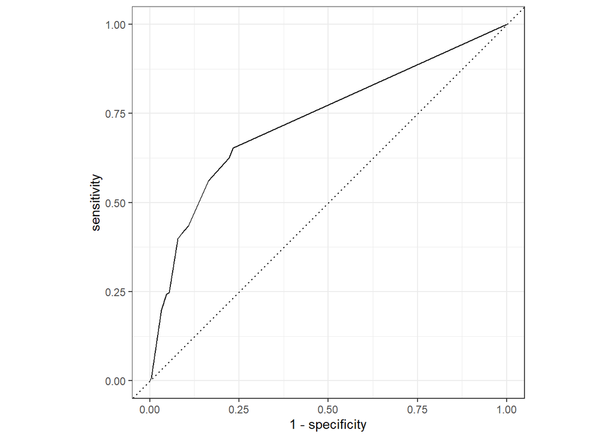

```r
# To plot the estimated ROC curve for the final model
wf_final_fit %>%
  collect_predictions() %>%
  roc_curve(Status, .pred_bad) %>%
  autoplot()
```

The final workflow object contains your finalised, fitted workflow that can be used for predicting on new data. If needed, you can investigate this model using some functions available under *tidymodels*:

```r
# check object final_tree for details on the decision tree nodes
final_tree <- extract_workflow(wf_final_fit)

# or, to plot the tree (if needed - not something you usually do with large decision trees)
# final_tree %>%
#   extract_fit_engine() %>%
#   plot()
# final_tree %>%
#   extract_fit_engine() %>%
#   text(cex = .5)
```

This predictive workflow is now ready to use! If you had new data (containing the same structure of predictors, but not the label) you could use it simply as:

```r
# Just to simulate data without labels:
Xtmp <- Xtest %>% select(-Status)

model_for_deployment <- wf_final_fit %>%
  extract_workflow()

my_predictions <- predict(model_for_deployment, new_data = Xtmp)

my_predictions
```

```
## # A tibble: 891 × 1
##    .pred_class
##    <fct>
##  1 good
##  2 good
##  3 good
##  4 bad
##  5 good
##  6 good
##  7 good
##  8 bad
##  9 good
## 10 good
## # ℹ 881 more rows
```

```r
# If you wanted to predict probabilities instead, you could do:
# my_predictions <- predict(model_for_deployment, new_data = Xtmp, type = "prob")
```

## TO DO

Now it’s your turn. After following the example above and experimenting with it in your own R session, try building and tuning a workflow for your own solution to Task II of the final coursework. Use the ideas above, read the `tidymodels` [tutorials and case studies](https://www.tidymodels.org/learn/), and good luck!

```r
df <- readRDS("df.rds")

# Ensure outcome is factor
df <- df %>%
  mutate(Class = as.factor(Class))

# ===============================================
# 1. Train/test split WITH GROUPING
# ===============================================

set.seed(20251119)

mysplits <- group_initial_split(
  df,
  prop  = 0.8,
  group = Info_group   # << IMPORTANT
)

df_train <- training(mysplits)
df_test  <- testing(mysplits)

df_train %>% count(Class) %>% mutate(prop = n/sum(n))
```

```
## # A tibble: 2 × 3
##   Class     n  prop
##   <fct> <int> <dbl>
## 1 -1     5831 0.591
## 2 1      4039 0.409
```

```r
df_test  %>% count(Class) %>% mutate(prop = n/sum(n))
```

```
## # A tibble: 2 × 3
##   Class     n  prop
##   <fct> <int> <dbl>
## 1 -1     1496 0.606
## 2 1       972 0.394
```

```r
# ===============================================
# 2. Preprocessing recipe
# ===============================================

X_recipe <- recipe(Class ~ ., data = df_train) %>%
  step_impute_mode(all_factor_predictors()) %>%
  step_impute_mean(all_numeric_predictors()) %>%
  step_normalize(all_numeric_predictors()) %>%
  step_pca(all_numeric_predictors())

# ===============================================
# 3. Baseline decision tree workflow
# ===============================================

dt_baseline <- decision_tree() %>%
  set_mode("classification") %>%
  set_engine("rpart")

wf_baseline <- workflow() %>%
  add_recipe(X_recipe) %>%
  add_model(dt_baseline)

# ===============================================
# 4. CROSS-VALIDATION with GROUPING
# ===============================================

set.seed(20251126)

folds <- group_vfold_cv(
  df_train,
  v     = 5,
  group = Info_group
)

metrics_to_use <- metric_set(
  accuracy,
  bal_accuracy,
  roc_auc,
  ppv,
  npv,
  f_meas
)

dt_baseline_fit <- wf_baseline %>%
  fit_resamples(
    resamples = folds,
    metrics   = metrics_to_use
  )

collect_metrics(dt_baseline_fit)
```

```
## # A tibble: 6 × 6
##   .metric      .estimator  mean     n std_err .config
##   <chr>        <chr>      <dbl> <int>   <dbl> <chr>
## 1 accuracy     binary     0.605     5  0.0109 pre0_mod0_post0
## 2 bal_accuracy binary     0.549     5  0.0107 pre0_mod0_post0
## 3 f_meas       binary     0.715     5  0.0134 pre0_mod0_post0
## 4 npv          binary     0.528     5  0.0239 pre0_mod0_post0
## 5 ppv          binary     0.625     5  0.0129 pre0_mod0_post0
## 6 roc_auc      binary     0.549     5  0.0107 pre0_mod0_post0
```

```r
# ===============================================
# 5. Hyperparameter tuning
# ===============================================

dt_tuned_model <- decision_tree(
  tree_depth = tune(),
  min_n      = tune()
) %>%
  set_mode("classification") %>%
  set_engine("rpart")

wf_tuned <- workflow() %>%
  add_recipe(X_recipe) %>%
  add_model(dt_tuned_model)

# Tuning folds (grouped)
set.seed(20251126)
tune_folds <- group_vfold_cv(
  df_train,
  v     = 3,
  group = Info_group
)

dt_grid <- grid_regular(
  min_n(),
  tree_depth(),
  levels = 5
)

set.seed(20251126)
dt_tuned <- wf_tuned %>%
  tune_grid(
    resamples = tune_folds,
    grid      = dt_grid,
    metrics   = metric_set(roc_auc, accuracy, ppv, npv),
    control   = control_grid(verbose = FALSE)
  )

collect_metrics(dt_tuned)
```

```
## # A tibble: 100 × 8
##    tree_depth min_n .metric  .estimator  mean     n std_err .config
##         <int> <int> <chr>    <chr>      <dbl> <int>   <dbl> <chr>
##  1          1     2 accuracy binary     0.602     3 0.00865 pre0_mod01_post0
##  2          1     2 npv      binary     0.536     3 0.0149  pre0_mod01_post0
##  3          1     2 ppv      binary     0.625     3 0.0190  pre0_mod01_post0
##  4          1     2 roc_auc  binary     0.558     3 0.0111  pre0_mod01_post0
##  5          1    11 accuracy binary     0.602     3 0.00865 pre0_mod02_post0
##  6          1    11 npv      binary     0.536     3 0.0149  pre0_mod02_post0
##  7          1    11 ppv      binary     0.625     3 0.0190  pre0_mod02_post0
##  8          1    11 roc_auc  binary     0.558     3 0.0111  pre0_mod02_post0
##  9          1    21 accuracy binary     0.602     3 0.00865 pre0_mod03_post0
## 10          1    21 npv      binary     0.536     3 0.0149  pre0_mod03_post0
## # ℹ 90 more rows
```

```r
dt_tuned %>%
  show_best(metric = "roc_auc", n = 10)
```

```
## # A tibble: 10 × 8
##    tree_depth min_n .metric .estimator  mean     n std_err .config
##         <int> <int> <chr>   <chr>      <dbl> <int>   <dbl> <chr>
##  1          1     2 roc_auc binary     0.558     3  0.0111 pre0_mod01_post0
##  2          1    11 roc_auc binary     0.558     3  0.0111 pre0_mod02_post0
##  3          1    21 roc_auc binary     0.558     3  0.0111 pre0_mod03_post0
##  4          1    30 roc_auc binary     0.558     3  0.0111 pre0_mod04_post0
##  5          1    40 roc_auc binary     0.558     3  0.0111 pre0_mod05_post0
##  6          4     2 roc_auc binary     0.558     3  0.0111 pre0_mod06_post0
##  7          4    11 roc_auc binary     0.558     3  0.0111 pre0_mod07_post0
##  8          4    21 roc_auc binary     0.558     3  0.0111 pre0_mod08_post0
##  9          4    30 roc_auc binary     0.558     3  0.0111 pre0_mod09_post0
## 10          4    40 roc_auc binary     0.558     3  0.0111 pre0_mod10_post0
```

```r
best_conf <- dt_tuned %>%
  select_best(metric = "roc_auc")


final_wf <- wf_tuned %>%
  finalize_workflow(best_conf)

# ===============================================
# 6. FINAL evaluation on the held-out test set
# ===============================================

final_fit <- final_wf %>%
  last_fit(
    split   = mysplits,
    metrics = metric_set(
      accuracy,
      bal_accuracy,
      roc_auc,
      ppv,
      npv,
      f_meas,
      sens,
      spec,
      mcc
    )
  )

final_fit %>% collect_metrics()
```

```
## # A tibble: 9 × 4
##   .metric      .estimator .estimate .config
##   <chr>        <chr>          <dbl> <chr>
## 1 accuracy     binary        0.604  pre0_mod0_post0
## 2 bal_accuracy binary        0.529  pre0_mod0_post0
## 3 ppv          binary        0.622  pre0_mod0_post0
## 4 npv          binary        0.493  pre0_mod0_post0
## 5 f_meas       binary        0.730  pre0_mod0_post0
## 6 sens         binary        0.882  pre0_mod0_post0
## 7 spec         binary        0.177  pre0_mod0_post0
## 8 mcc          binary        0.0822 pre0_mod0_post0
## 9 roc_auc      binary        0.529  pre0_mod0_post0
```

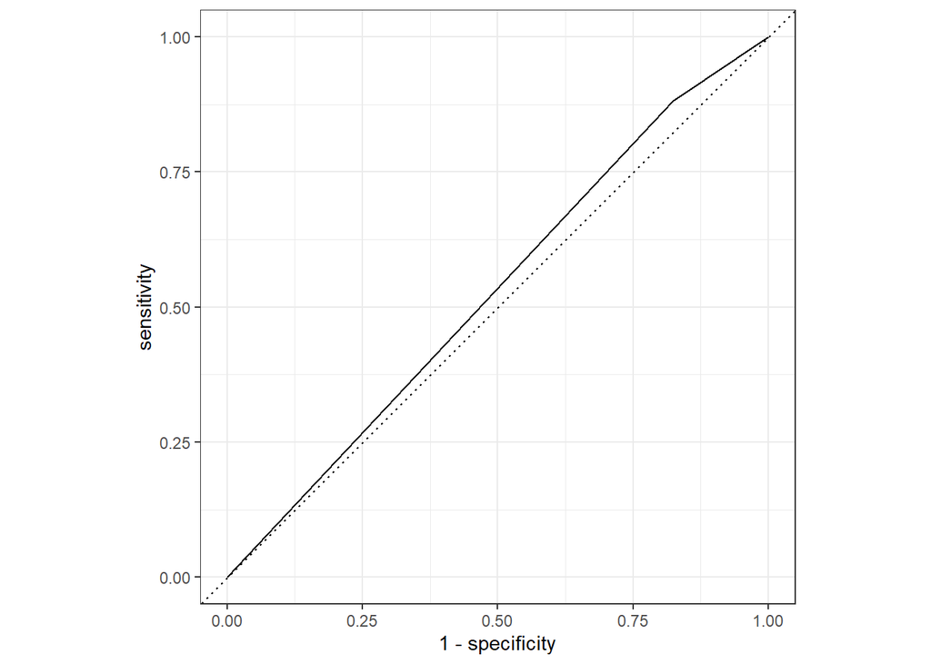

```r
# ===============================================
# 7. ROC curve
# ===============================================

final_preds <- final_fit %>% collect_predictions()
positive_class <- levels(final_preds$Class)[1]
prob_col <- paste0(".pred_", positive_class)

final_preds %>%
  roc_curve(Class, !!rlang::sym(prob_col)) %>%
  autoplot()
```

```r
# ===============================================
# 8. Predict on new data
# ===============================================

df_new <- df_test %>% select(-Class)

model_for_deployment <- final_fit %>%
  extract_workflow()

pred_classes <- predict(model_for_deployment, new_data = df_new)
pred_probs   <- predict(model_for_deployment, new_data = df_new, type = "prob")

head(pred_classes)
```

```
## # A tibble: 6 × 1
##   .pred_class
##   <fct>
## 1 -1
## 2 -1
## 3 -1
## 4 -1
## 5 1
## 6 -1
```

```r
head(pred_probs)
```

```
## # A tibble: 6 × 2
##   `.pred_-1` .pred_1
##        <dbl>   <dbl>
## 1          1       0
## 2          1       0
## 3          1       0
## 4          1       0
## 5          0       1
## 6          1       0
```